# Assignment 5 Suh

```r
# residuals are normally distributed


# linear regression for females predicted by year

females_lm <- lm(total_females ~ year, data = enroll_totals)
summary(females_lm)
```

```
##
## Call:
## lm(formula = total_females ~ year, data = enroll_totals)
##
## Residuals:
##    Min     1Q Median     3Q    Max
## -89397 -48101  -7633  45267 129727
##
## Coefficients:
##               Estimate Std. Error t value Pr(>|t|)
## (Intercept) -5.896e+07  1.161e+06  -50.77   <2e-16 ***
## year         3.013e+04  5.832e+02   51.66   <2e-16 ***
## ---
## Signif. codes:  0 '***' 0.001 '**' 0.01 '*' 0.05 '.' 0.1 ' ' 1
##
## Residual standard error: 57730 on 47 degrees of freedom
## Multiple R-squared:  0.9827, Adjusted R-squared:  0.9823
## F-statistic:  2669 on 1 and 47 DF,  p-value: < 2.2e-16
```

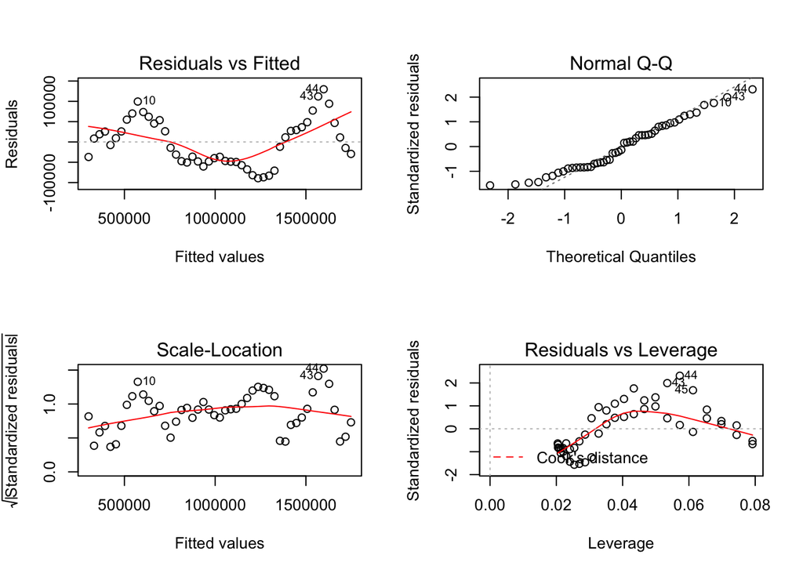

```r
#total_female_enrollment = -5.896e+07 + 3.013e+04*year

# at year 0 for both models, we have negative enrollment, which is impossible. This means that we likely will not have a good model for past models.

# check diagnostic plots
par(mfrow = c(2,2))
plot(females_lm)
```

```r
# residuals are normally distributed

# correlation testing for males vs year
cor.test(enroll_totals$year, enroll_totals$total_males)
```

```
##
##  Pearson's product-moment correlation
##
## data:  enroll_totals$year and enroll_totals$total_males
## t = 16.612, df = 47, p-value < 2.2e-16
## alternative hypothesis: true correlation is not equal to 0
## 95 percent confidence interval:
##  0.8690777 0.9568547
## sample estimates:
##       cor
## 0.9243741
```

```r
# strong positive correlation

# correlation testing for females vs year
cor.test(enroll_totals$year, enroll_totals$total_females)
```

```
##
##  Pearson's product-moment correlation
##
## data:  enroll_totals$year and enroll_totals$total_females
## t = 51.659, df = 47, p-value < 2.2e-16
## alternative hypothesis: true correlation is not equal to 0
## 95 percent confidence interval:
##  0.9845609 0.9951144
## sample estimates:
##       cor
## 0.9913086
```

```r
#even stronger positive correlation

# Need to interpret.
```

```r
m_f_enroll_lmtbl <- stargazer(males_lm, females_lm, type = "html") # not working
```

|  | *Dependent variable:* |  |
| --- | --- | --- |
|  | total_males | total_females |
|  | (1) | (2) |
| year | 9,069.301*** | 30,126.030*** |
|  | (545.955) | (583.175) |
| Constant | -17,112,153.000*** | -58,955,502.000*** |
|  | (1,087,024.000) | (1,161,132.000) |
| Observations | 49 | 49 |
| R<sup>2</sup> | 0.854 | 0.983 |
| Adjusted R<sup>2</sup> | 0.851 | 0.982 |
| Residual Std. Error (df = 47) | 54,046.810 | 57,731.420 |
| F Statistic (df = 1; 47) | 275.952*** | 2,668.611*** |
| *Note:* | p<0.1; p<0.05; p<0.01 |  |

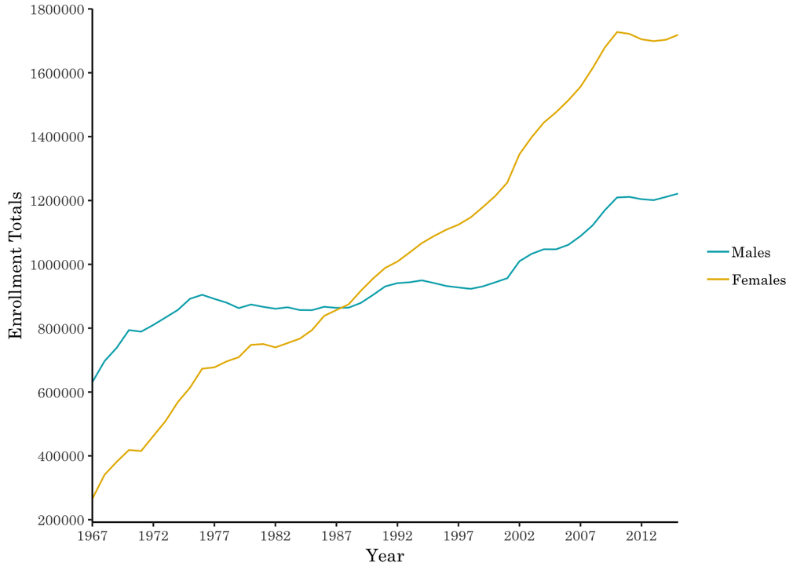

```r
# FINAL GRAPH: Make a time series graph with year on x axis and totals on y axis

totals_line <- ggplot(enroll_totals, aes(x = year)) +
  geom_line(aes(y = total_males, color = "blue")) +
  geom_line(aes(y = total_females, color = "red")) +
  theme_classic() +
  scale_x_continuous(expand = c(0,0), breaks = seq(1967, 2015, by = 5), limits = c(1967, 2015)) +
  scale_y_continuous(breaks = seq(0, 2200000, by = 200000)) +
  scale_color_manual(values = c("#00AFBB", "#E7B800"), labels = c("Males", "Females")) +
  labs(x = "Year", y = "Enrollment Totals") +
  theme(text = element_text(family = "Century Schoolbook"), legend.title=element_blank())

totals_line
```

**2. Shifts in female PhD recipients by field (1985, 2000, and 2015). Describe if and how there was a shift in PhDs awarded to females in four fields (Physical and Earth Sciences, Engineering, Education, and Humanities & Arts) in 1985, 2000, and 2015. Describe your results statistically, in a graph or table, and in text. Note: There are several ways that you can interpret this question. You are invited to decide which you think is/are most interesting. Just be really clear about what you are asking/answering in your report.**

```r
female_phd <- read_csv("PhDs by Field 1985 - 2015.csv")
female_phd1 <- select(female_phd, -year)  # delete year column

rownames(female_phd1) <- c("1985", "2000", "2015")   # name rows as year
female_phd_prop <- prop.table(as.matrix(female_phd1), 1)  #create proportion table

female_phd_x2 <- chisq.test(female_phd1)   #perform chisquare test

female_phd_x2  ####### ilayda add total enrollment column #######
```

```
##
##  Pearson's Chi-squared test
##
## data:  female_phd1
## X-squared = 2073.3, df = 6, p-value < 2.2e-16
```

```r
# females moved out of education, and into the sciences and engineering (engineering especially). The humanities generally stayed the same.

# Ilayda make table adding in the total enrollment of females column
```

**3. Male and female salaries for starting postdoctoral and other employment positions (2015). Compare median salaries for male and female doctorate recipients in 2015. Answer these two questions: Does median salary differ significantly between male and female starting postdoc positions? Does median salary differ significantly between male and female PhD recipients in non-postdoc employment positions?**